# Special Events Visualization - Part 1

Ci (Jessie) Yang

Last Updated: October 16, 2018

This is an example of visuals that we can create visualizations for a specific location and buffer zone around the location where we have model outputs on.

# Introduction

The objective of the special event analysis is to understand if EDT or Waze events are driven by locations and times with special events, for example, football and baseball events, that could potentially have huge impact on traffic flow on the road network. We expect that a higer than normal traffic demand due to the attendance of the special events.

> Data

There are two types of data used in the analysis: Special events and metric data.

**1. Special Events in two example locations in Maryland**

- FedEx Field: NFL Stadium in Washington D.C. area Four football games in August and September (75k avg attendance) Major concerts in June and August (46k avg attendance) International Soccer game in July (49k in attendance)
- Camden Yards: MLB stadium in Baltimore, MD 81 baseball games (25k avg attendance)

**2. Metric Data**

The metric data is based on the random forest model output (MD_All_Model_30.csv) of running a full dataset of Maryland beween April 1st to September 30th in 2017. The data include model estimates, model residuals, Waze jams, Hazards, and EDT accidents.

After evaluating the data quality and availability of the data, we selected following metrics that are relatively good in representing the travel patterns on the road. We initially considered all six variables, but we only presented the first five in the special event presentation to the sponsors.

- Number of EDT Accidents (Model Dependent Variable)
- Number of Waze Accidents
- Number of Waze Jams
- Number of Hazards On Shoulder (nHazardOnShoulder)
- Number of Hazards On Road (nHazardOnRoad)
- Number of Hazards Weather (nHazardWeather) According to Michelle Gilmore, this should be one of the three categories of Waze event (Accidents, Jam, and Hazard/Weather). However, in the dataset, nHazardWeather is smaller than sum of the sub-categories (e.g., nHazardOnShoulder, nHazardOnRoad). Due to the data quality issue of this variable, we did not use it in the analysis.
- Probability of NonCrash and Crash This is real probability from Random Forest model. The probability has converted to based on the threshold ~ 0.2 using the built-in function in Random Forest. We analyzed this variable in spreadsheet, but did not present the results to the sponsors.

To understand relationship between special event and traffic patterns, used 3 buffer zones based on the distance from the event location:

- 1 mile (8-9 grid cells)
- 3 mile (41-42 grid cells)
- 5 mile (96-100 grid cells)
  - 12% grid cells in FedEx Field 5 mile buffer have no data due to outside the Maryland state border (in DC area).

The plot followed compares the average daily total counts of the metrics of all grid cells for 3 mile buffer zone.

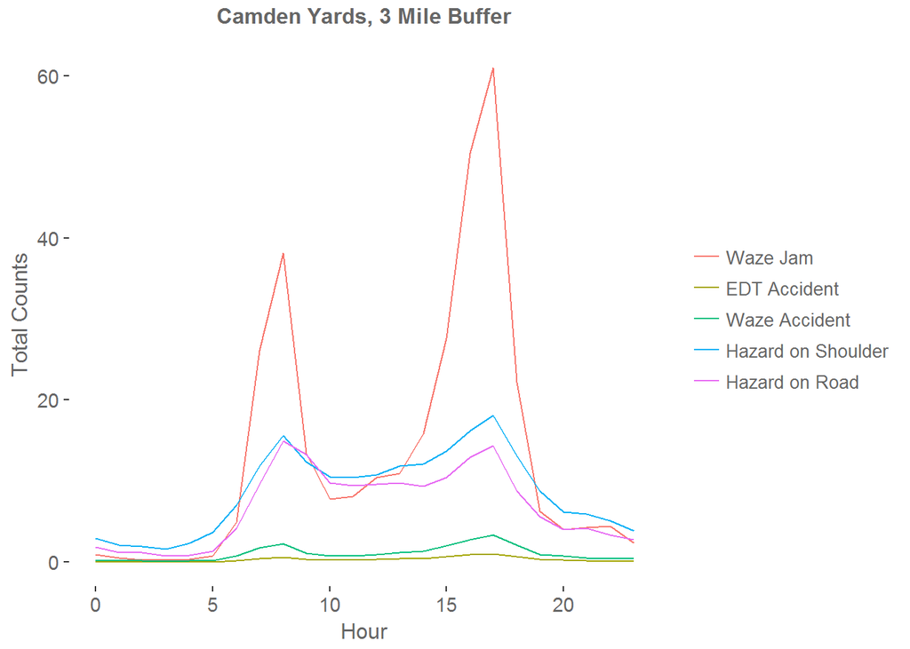

> Archived Notes

Here are notes taken for iterative edits or comments from the team and the sponsor. Most of them have been addressed, there are still a few bullet points are placed in the parking lot for future analysis.

**To do 8/23/2018:**

- total/average/max (point/line) number of accidents/jams for every day (done)
  - plot on top of each other for the NoEvents with a different color. Use other colors for a type of special events. 4/23 (4/16 easter), 5/21 (5/29 memorial day, 5/14 mother’s day), 7/02 weekends near holidays.
  - Do both 3-miles and 1-mile. Removing zeros.
  - Panels by month.
  - add shadebox for event duration
- add function for visuals (done)
- number of accidents per gridcell per hour (done)
- boxplot of accidents over 42 grid cells. (done)
- look at hour aggregation
- heatmap for each hour
- smaller buffer zone, 0.25, 0.5, 1 mile radius
  - update SpecialEventsExpand dataset (done)
  - update the analysis and visuals (done)
- Easten shore beach - Bay Bridge area (7/4, 9/4 Labor Day, 3lanes both ways) for a typical holiday pattern
- follow up with Erika tomorrow (done)
- write one plot function in stead of multiple plot functions. (done)

**Dave’s feedback 8/29/2018:**

- try large buffer, e.g., 5 miles (Dan’s suggestion: work with individual lag/lons instead of grid cells)
- broader patterns - can we add baseball game,(Michelle’s comments: baseball games are usually hosted in urban areas with intercity activities and good public transportation, less parking. Erika - How far aways is the parking. Look that the parking in the buffer).
- Two days of week (Saturday, Wednesday)
- Extend the 23 hours through another 6 hours, change time window from 5 am to 5 am.
- Other types of metric, Hazards on the roads, car stopped on shoulders. Car stopped on shoulders.
- Other location: for exmaple, University football games.
- Can we try to make this a little more of hot spots, can we do this on a grid cell level.

# Visualizations

## HeatMap

The heatmaps specify the daily total events of all grid-cells within the buffer zone of a special event location, averaged through a specific weekday. Each weekday can be plotted separately, or we can plot all weekdays in one plot.

### Heatmap Example 1

The first example shows Fedex Field of Sundays (and all weekdays) of a 3 mile buffer zone. We observe a strong pattern for the higher # of Jam/Accident before and after event, this might also due to the fact that smaller # of special events are available in this location.

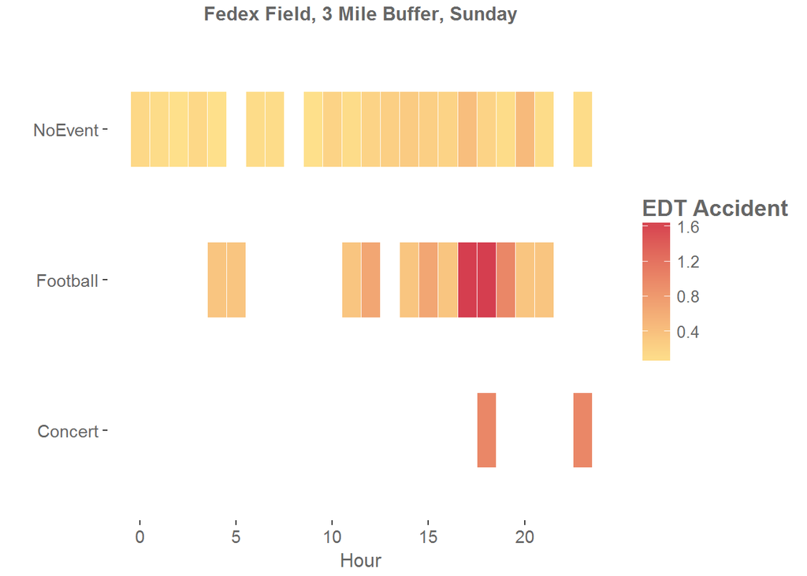

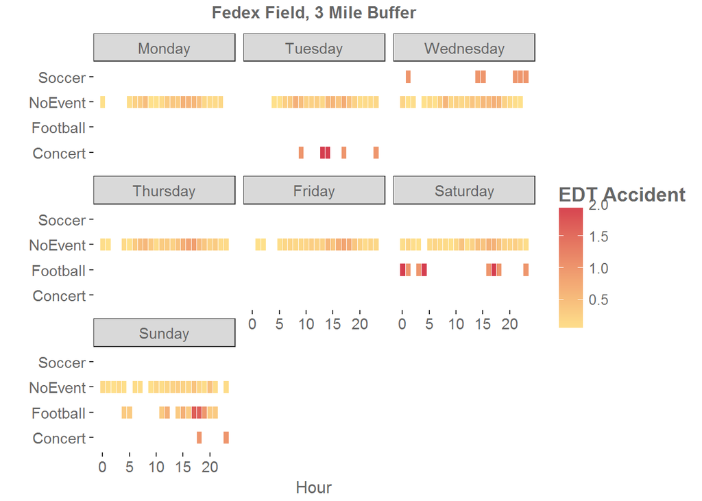

### Heatmap Example 2

There are 12 - 13 baseball events at each day of week during the season. For example, there are baseball games every other Saturday, a total of 13 baseball games on Saturdays.

Takeaways:

- There are significant differences between weekday and weekends.
- No much difference between Events and Noevents during weekdays
- The game does not attract much more traffic because 1) Camden Yards is located in urban area (Baltimore), with good public transportation/rideshare/bike/ped access to the stadium, and 2) regular commuting traffic might be reduced because people are trying to avoid the traffic during an event day.
- If events happen in a regular basis, in this case, baseball games, the differences between events and non-event days are not strong any more.

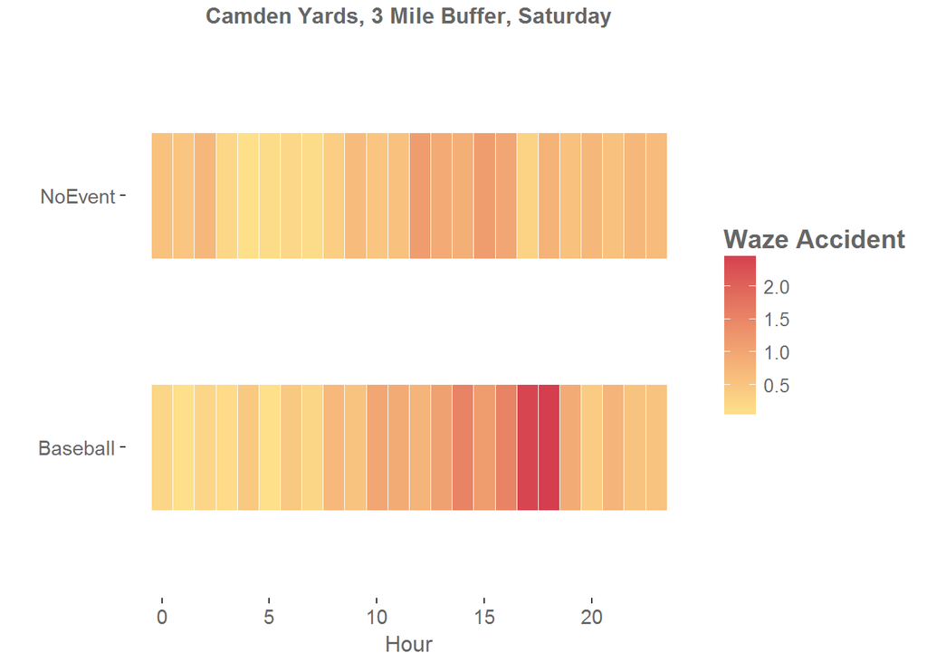

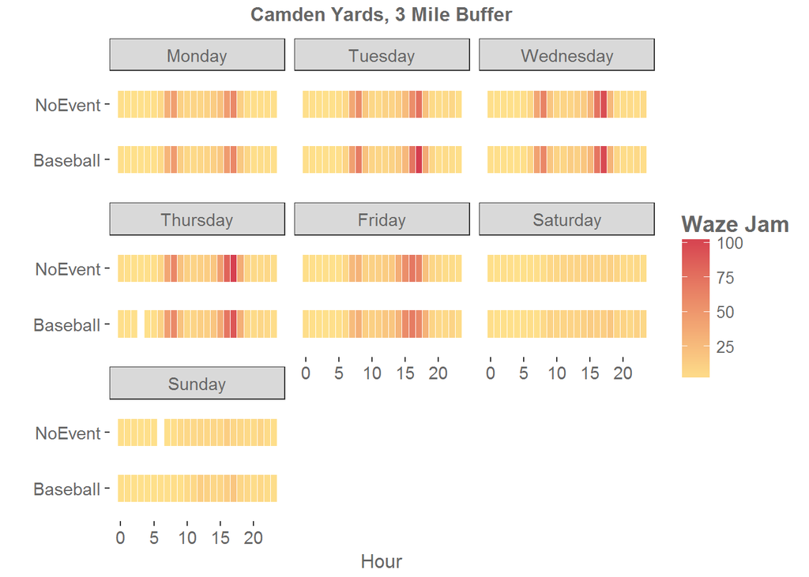

[figure not shown]

## Time Series Plots

### Time series plot of specific days

Total/average/max (point/line) number of accidents/jams for all grid cells everyday, for two Sundays, one with event and another without special event: “2017-09-10”,“2017-09-17”. We shaded the period of special events for better visualization of how the patterns changes across time of day.

Key observations:

- Traffic is typically worse before and after as people are entering and exiting event location.
- Observed more Waze events and EDT accidents before and after the event period rather than during the event period.

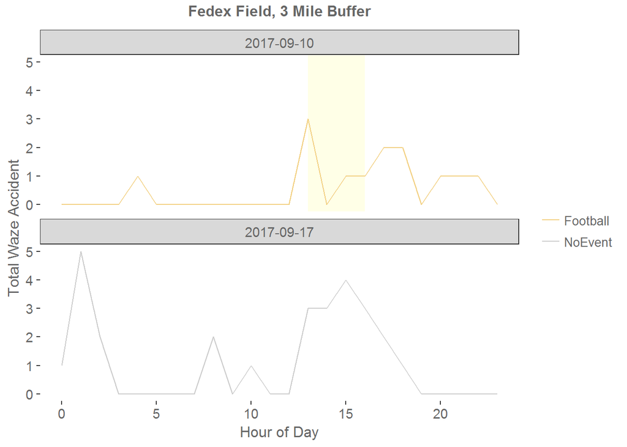

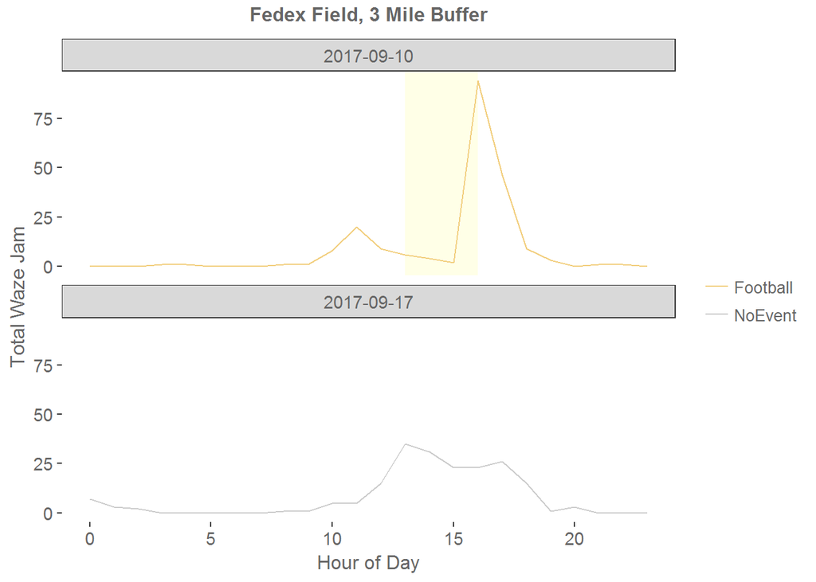

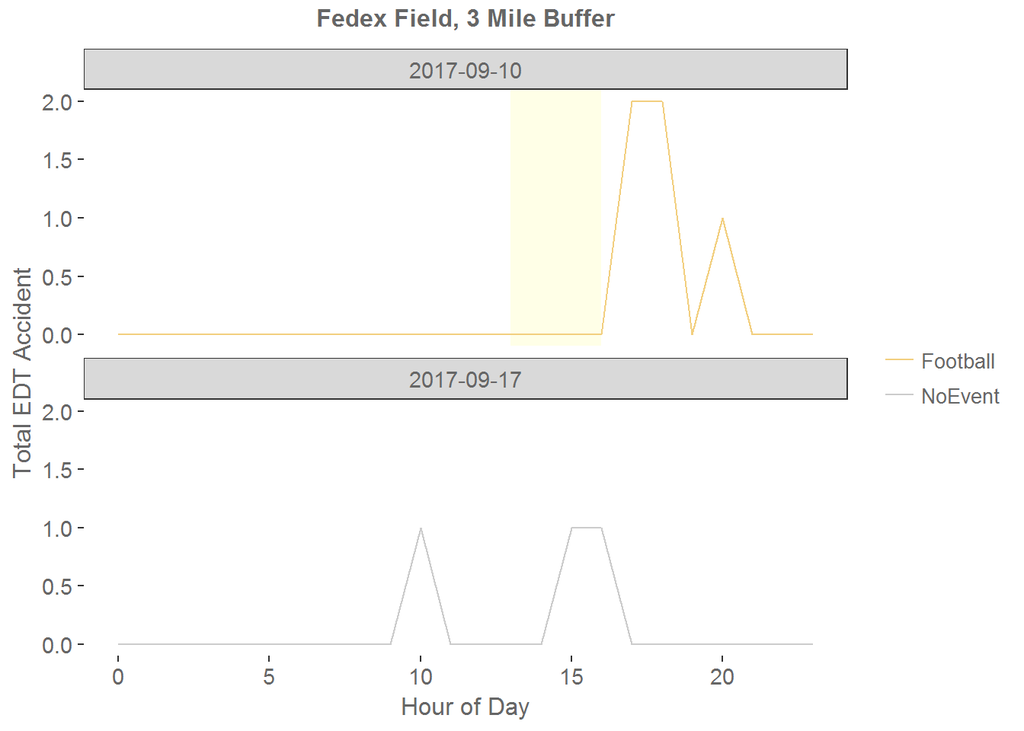

### Time Series Plots by Mile Buffers

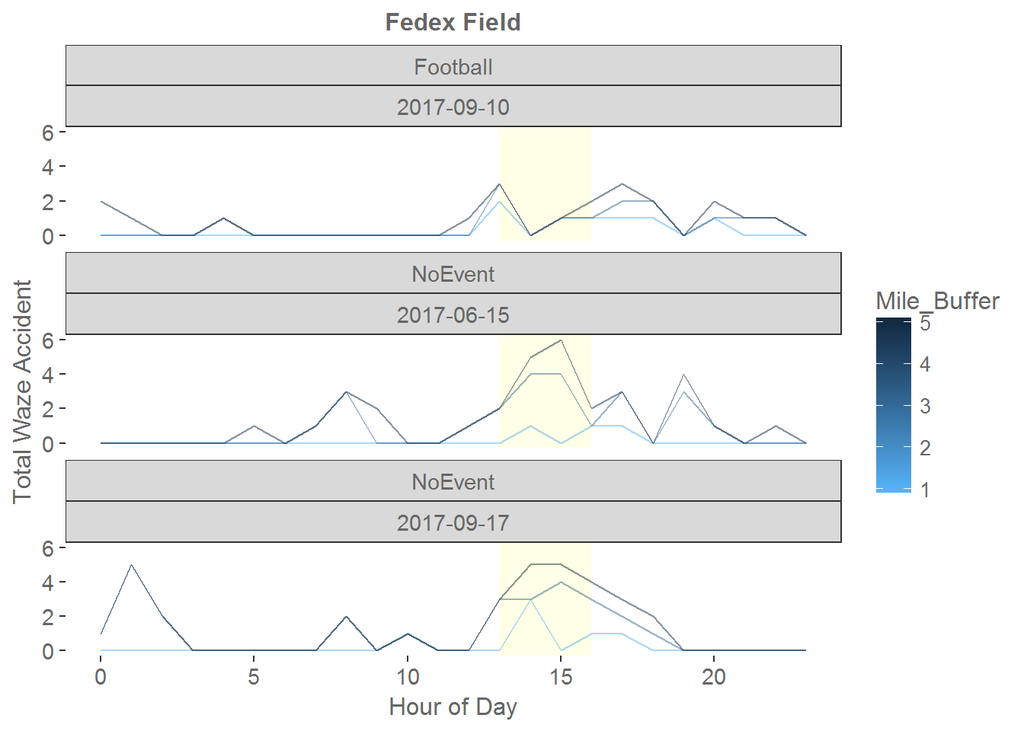

### Time Series Plot by Month

Use Camden Yards 3 mile buffer zone on Saturday as an example, the plot shows the total Waze accidents by months and the color represent the type of events. The shades are event period for however many special events available during all Saturdays of each month.

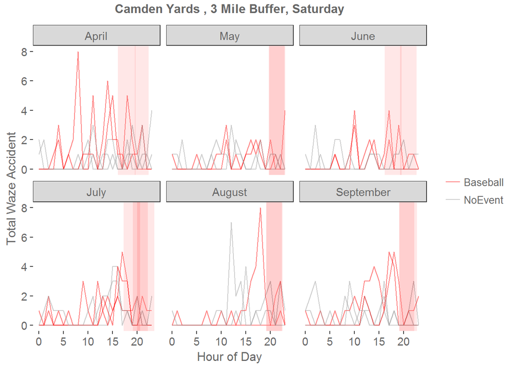

### Time Series Plot by Day

Use Camden Yards 3 mile buffer zone on Saturday as an example, the plot shows the total Waze accidents by day and the color represent the type of events. The shades are event period for however many special events available during all Saturdays of each month.

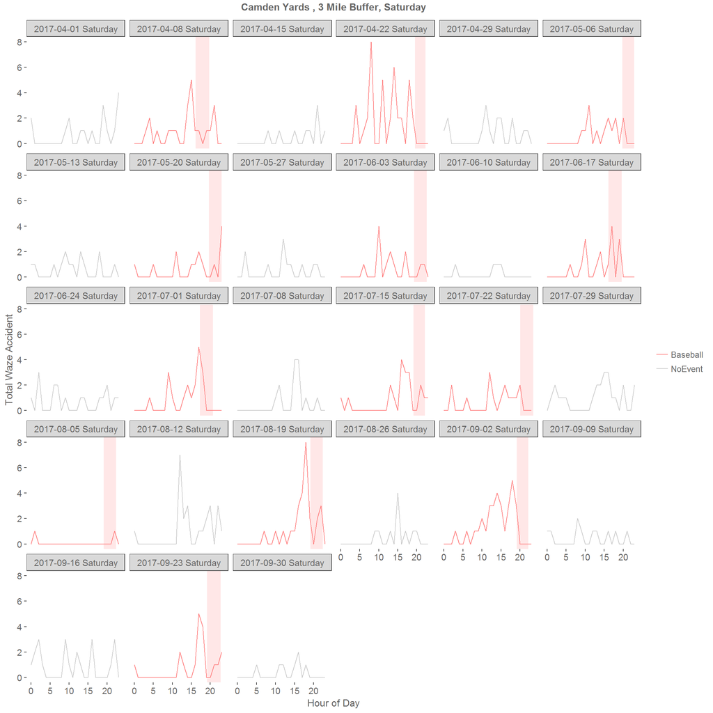